# RNA-seq Mouse Placenta

Ha T. H. Vu

Documentation for the analysis of mouse placental RNA-seq data at e7.5, e8.5 and e9.5.

## 1. Step 1: FastQC - Quality control of reads:

Version: 0.11.7

```bash
cd /work/LAS/geetu-lab/hhvu/project1_2/rna-seq/0_rawData/fastqFiles
module load fastqc
fastqc *.fastq
```

## 2. Step 2: Trimmomatic - Trimming out adapter contents, overrepresented sequences and low quality base pairs:

Version: 0.39

```bash
module load trimmomatic
cd /work/LAS/geetu-lab/hhvu/project1_2/rna-seq/0_rawData/fastq.gz
#example
java -jar /home/hhvu/Trimmomatic-0.39/trimmomatic-0.39.jar SE -phred33 inFiles ./outFiles.trimmed.fastq.gz ILLUMINACLIP:/home/hhvu/Trimmomatic-0.39/adapters/TruSeq3-SE.fa:2:30:10 LEADING:10 TRAILING:10 SLIDINGWINDOW:4:15 MINLEN:36
```

## 3. Step 3: Kallisto - Pseudoalignment and quantification:

Merge files from different technical runs:

```bash
cat file1.fatstq.gz file2.fastq.gz > merge.fastq.gz
```

Kallisto  
Version: 0.43.1  
Index files were build with cDNA on autosomal and sex chromosomes of the mouse genome (GRCm38.p6) from Ensembl release 98.

```bash
kallisto quant -i /work/LAS/geetu-lab/hhvu/index_files/mm10/kallisto-ensembl/mm10.idx -o ourdir/S49 --single -l 200 -s 30 -b 100 S49.fastq.gz
```

## 4. Step 4: Quality control

```r
#load necessary libraries
library("dplyr", suppressMessages())
library("tidyverse", suppressMessages())
library("biomaRt", suppressMessages())
```

```r
library("ggplot2", suppressMessages())
library("dendextend", suppressMessages())
library("matrixStats", suppressMessages())
library("stats", suppressMessages())
library("pca3d", suppressMessages())
library("scatterplot3d", suppressMessages())
library("pheatmap", suppressMessages())
```

First, we filter the transcripts based on raw counts.

```r
#load necessary files
coding <- read.table("Files/Mus_musculus_grcm38_coding_transcripts.txt", header = F)
est_counts <- read.csv("Files/estCounts_allSamples.tsv", header = TRUE, sep = "\t", stringsAsFactors=FALSE)

#reformat count file
est_counts <- est_counts[order(est_counts$target_id),]
rownames(est_counts) <- est_counts$target_id #make transcript names to be row names
est_counts <- est_counts[, -c(1, 20, 21)] #exclude non-count columns

#make mean count table
mean_cts <- data.frame(trans=rownames(est_counts),
                       E7.5_mean=NA,
                       E8.5_mean=NA,
                       E9.5_mean=NA)
mean_cts$E7.5_mean <- rowMeans(est_counts[, c("E7.5_1", "E7.5_2", "E7.5_3", "E7.5_4", "E7.5_5", "E7.5_6")])
mean_cts$E8.5_mean <- rowMeans(est_counts[, c("E8.5_1", "E8.5_2", "E8.5_3", "E8.5_4", "E8.5_5", "E8.5_6")])
mean_cts$E9.5_mean <- rowMeans(est_counts[, c("E9.5_1", "E9.5_2", "E9.5_3", "E9.5_4", "E9.5_5", "E9.5_6")])
row.names(mean_cts) <- mean_cts$trans
mean_cts <- mean_cts[,2:ncol(mean_cts)]

#filter low count transcripts
basic_filter <- function (row, min_reads = 20, min_prop = 1/3) {
  mean(row >= min_reads) >= min_prop
}
keep <- apply(mean_cts, 1, basic_filter) #1 means apply the function to each row
```

Next, we carry out PCA and hierarchical clustering analysis. We will use scaled TPM values for this step. From the retained transcripts, we focused on the top 50% most variable transcripts.

```r
tpm <- read.csv("Files/TPM_allSamples.tsv", header = TRUE, sep = "\t", stringsAsFactors=FALSE)

#reformat count file
tpm <- tpm[order(tpm$target_id),]
row.names(tpm) <- tpm$target_id
tpm <- tpm[,-c(1, 20, 21)]
tpm[] <- lapply(tpm, function(x) as.numeric(as.character(x)))
#filter out the low count transcripts according to the est_counts filtering above
tpm <- tpm[keep, ]

#calculate the variance between 3 time points
#here I take the average of each time point to make sure the variance is only calculated based on time points
#if not doing this, the variance may include biological variances between replicates also
mean_tpm <- data.frame(trans=rownames(tpm),
                       E7.5_mean=NA,
                       E8.5_mean=NA,
                       E9.5_mean=NA)
mean_tpm$E7.5_mean <- rowMeans(tpm[, c("E7.5_1", "E7.5_2", "E7.5_3", "E7.5_4", "E7.5_5", "E7.5_6")])
mean_tpm$E8.5_mean <- rowMeans(tpm[, c("E8.5_1", "E8.5_2", "E8.5_3", "E8.5_4", "E8.5_5", "E8.5_6")])
mean_tpm$E9.5_mean <- rowMeans(tpm[, c("E9.5_1", "E9.5_2", "E9.5_3", "E9.5_4", "E9.5_5", "E9.5_6")])
row.names(mean_tpm) <- mean_tpm$trans
mean_tpm <- mean_tpm[,2:ncol(mean_tpm)]
mean_tpm$var <- matrixStats::rowVars(as.matrix(mean_tpm)) #calculate the variance
mean_tpm_keep <- subset(mean_tpm, mean_tpm$var > quantile(mean_tpm$var, 0.50)) #keep the top 50% most variable transcripts

tpm1 <- subset(tpm, rownames(tpm) %in% rownames(mean_tpm_keep))
tpm1[] <- lapply(tpm1, function(x) as.numeric(as.character(x)))
#center and scale the data, for further analysis
tpm2 <- apply(tpm1, 1, function(x) (x-mean(x))/sd(x))
tpm2 <- t(tpm2)
tpm2 <- as.data.frame(tpm2)
```

PCA analysis:

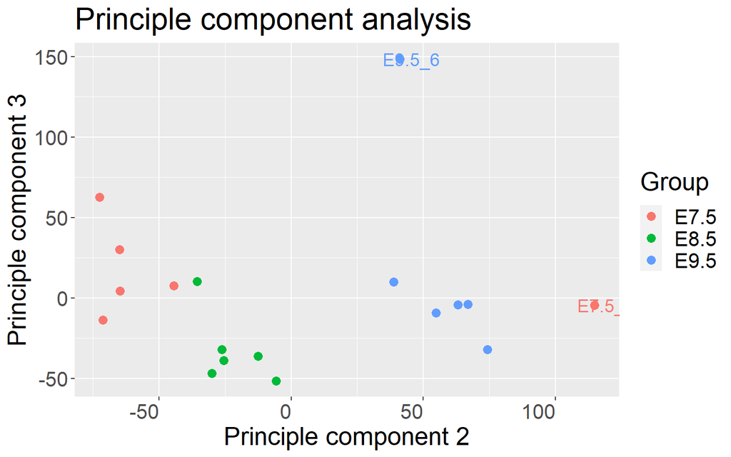

```r
pca <- prcomp(t(tpm2))
#summary(pca) #run if we want to see the summary

#2D PCA
df_out <- as.data.frame(pca$x)
df_out$Group <- as.factor(c(rep("E7.5", 6),
                            rep("E8.5", 6),
                            rep("E9.5", 6)))
#the following plot with PC2 and PC3 showed clearly E9.5_6 is an outlier
ggplot(df_out, aes(x=PC2, y=PC3, color=Group, label=ifelse(colnames(tpm1) == c("E7.5_1", "E9.5_6"), as.character(colnames(tpm1)), ''))) +
  geom_text(hjust=0.3,size=5, show.legend = F) + geom_point(size=3) +
  labs(title="Principle component analysis", x="Principle component 2", y="Principle component 3") +
  theme(text = element_text(size=20), axis.text.x = element_text(angle=0, hjust=1))
```

Hierarchical clustering analysis:

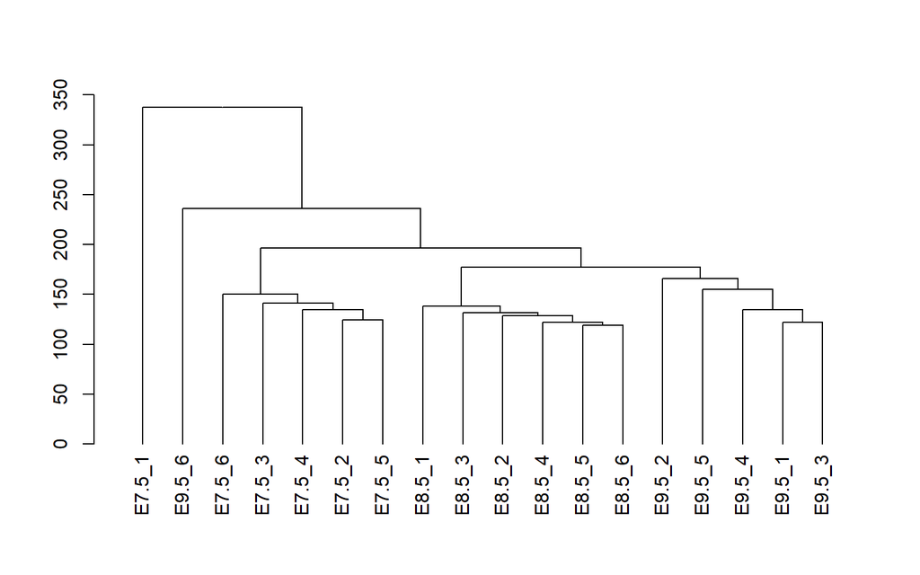

```r
hc <- hclust(dist(t(tpm2)), "ave")
dend <- as.dendrogram(hc)
dend %>% hang.dendrogram(hang = -1) %>% plot()
```

Based on the PCA and hierarchical clustering analysis on samples, the sample 1 of E7.5 and 6 of E9.5 did not cluster with their time points, hence identified as outliers.